# Actividad Práctica 2

### RMSE

En este caso, conviene comparar cada caso individualmente y sacar conclusiones finales

#### Comparación RMSE entrenamiento

```python
df_all_train = pd.concat([test_simple_train, test_lstm_train],axis=1)
```

```python
df_all_train.columns = [ 'trainA_simpleRNN',
                         'trainB_simpleRNN',
                         'trainC_simpleRNN',
                         'trainD_simpleRNN',
                         'trainA_lstm',
                         'trainB_lstm',
                         'trainC_lstm',
                         'trainD_lstm']
```

```python
df_all_train
```

|  | trainA_simpleRNN | trainB_simpleRNN | trainC_simpleRNN | trainD_simpleRNN | trainA_lstm | trainB_lstm | trainC_lstm | trainD_lstm |
| --- | --- | --- | --- | --- | --- | --- | --- | --- |
| 0 | 21.91 | 22.36 | 22.09 | 31.54 | 26.11 | 29.04 | 23.14 | 32.76 |
| 1 | 21.43 | 21.80 | 22.57 | 30.25 | 29.07 | 26.31 | 22.63 | 32.82 |
| 2 | 21.66 | 18.28 | 21.85 | 25.67 | 26.41 | 31.61 | 23.44 | 31.99 |
| 3 | 22.17 | 19.61 | 21.35 | 33.70 | 30.49 | 30.81 | 23.67 | 31.77 |
| 4 | 22.22 | 19.48 | 21.18 | 29.99 | 33.42 | 28.59 | 22.27 | 34.67 |

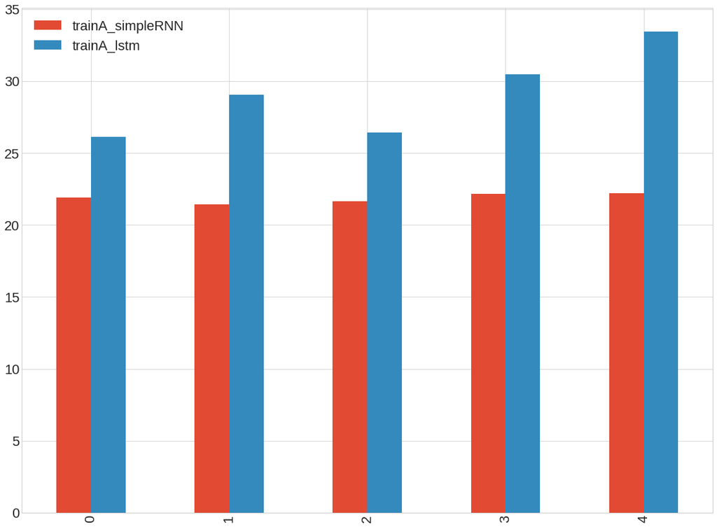

```python
df_all_train[['trainA_simpleRNN','trainA_lstm']].plot.bar()
```

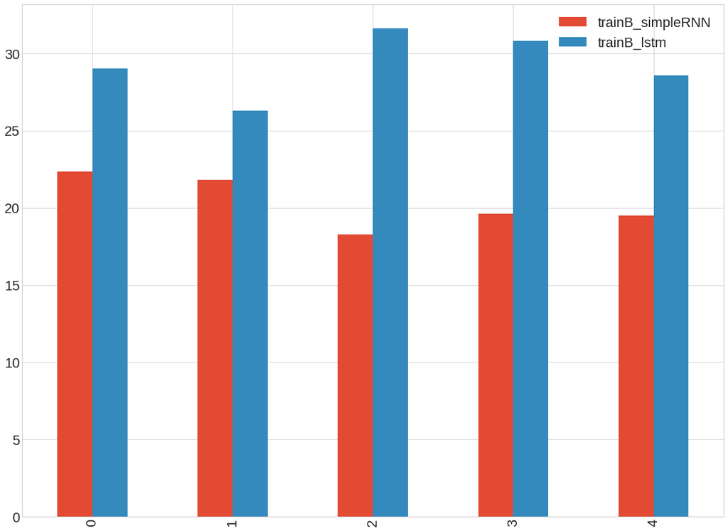

```python
df_all_train[['trainB_simpleRNN','trainB_lstm']].plot.bar()
```

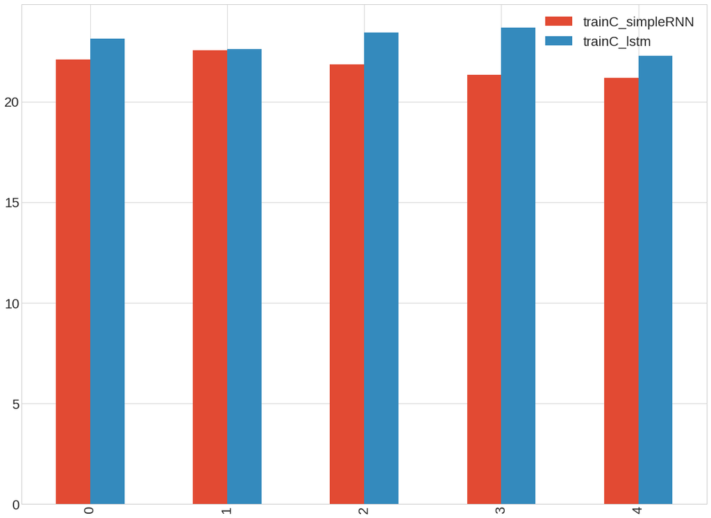

```python
df_all_train[['trainC_simpleRNN','trainC_lstm']].plot.bar()
```

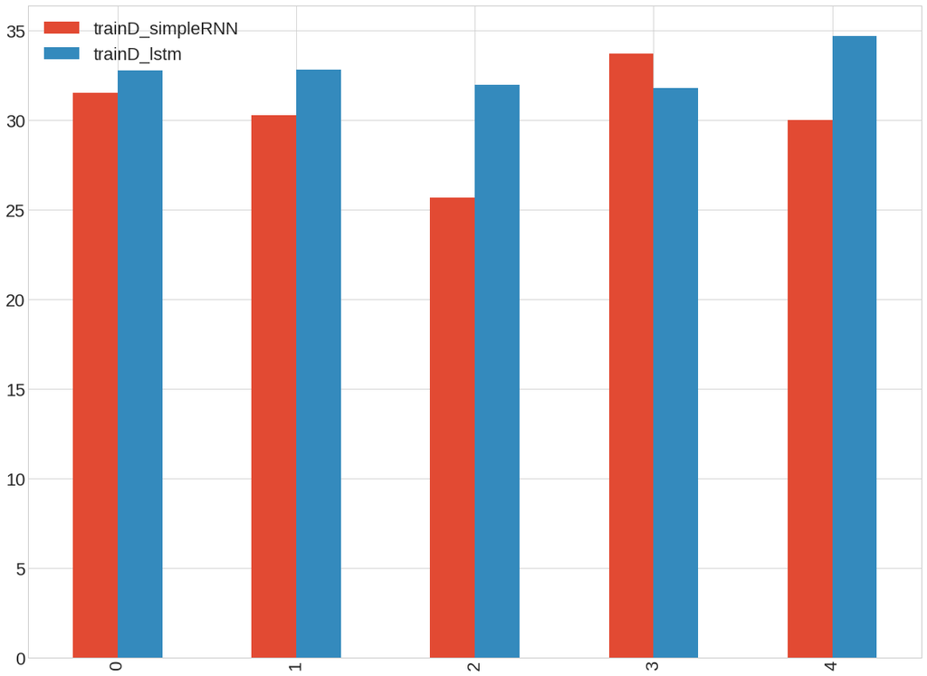

```python
df_all_train[['trainD_simpleRNN','trainD_lstm']].plot.bar()
```

#### Comparación RMSE en testing

```python
df_all_test = pd.concat([test_simple_testing, test_lstm_testing],axis=1)
```

```python
df_all_test
```

|  | testA | testB | testC | testD | test_caseA | test_caseB | test_caseC | test_caseD |
| --- | --- | --- | --- | --- | --- | --- | --- | --- |
| 0 | 46.80 | 57.13 | 46.71 | 83.60 | 55.98 | 59.71 | 52.52 | 89.20 |
| 1 | 54.20 | 67.79 | 44.77 | 82.93 | 66.98 | 56.29 | 59.35 | 81.21 |
| 2 | 46.47 | 44.50 | 48.42 | 62.99 | 62.96 | 66.81 | 51.84 | 85.55 |
| 3 | 62.59 | 40.57 | 51.81 | 95.03 | 65.83 | 66.62 | 68.89 | 76.87 |
| 4 | 61.48 | 46.26 | 52.12 | 80.83 | 79.78 | 59.97 | 51.85 | 88.84 |

```python
df_all_test.columns = ['testA_simpleRNN',
                       'testB_simpleRNN',
                       'testC_simpleRNN',
                       'testD_simpleRNN',
                       'testA_lstm',
                       'testB_lstm',
                       'testC_lstm',
                       'testD_lstm']
```

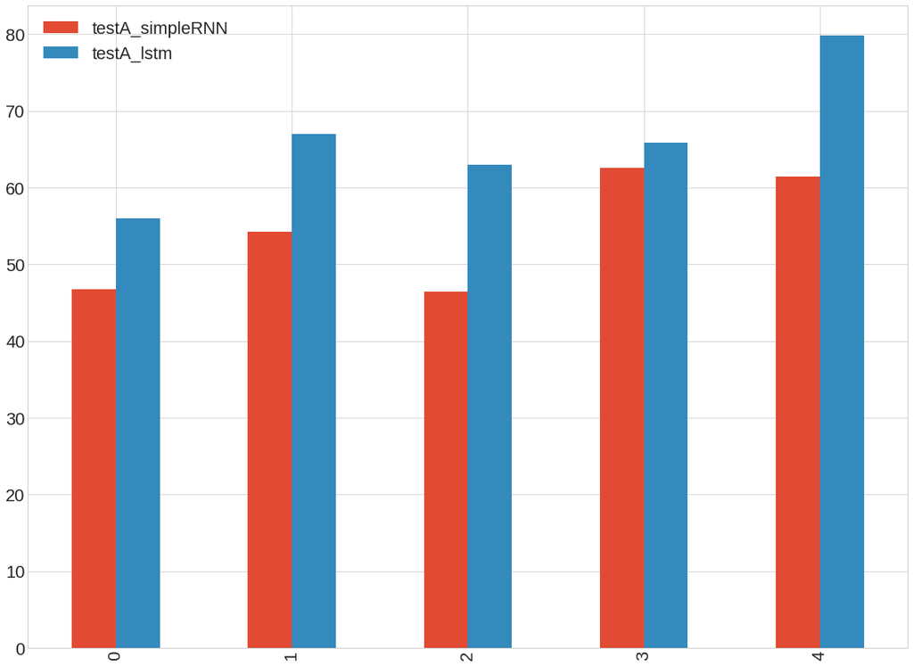

```python
df_all_test[['testA_simpleRNN','testA_lstm']].plot.bar()
```

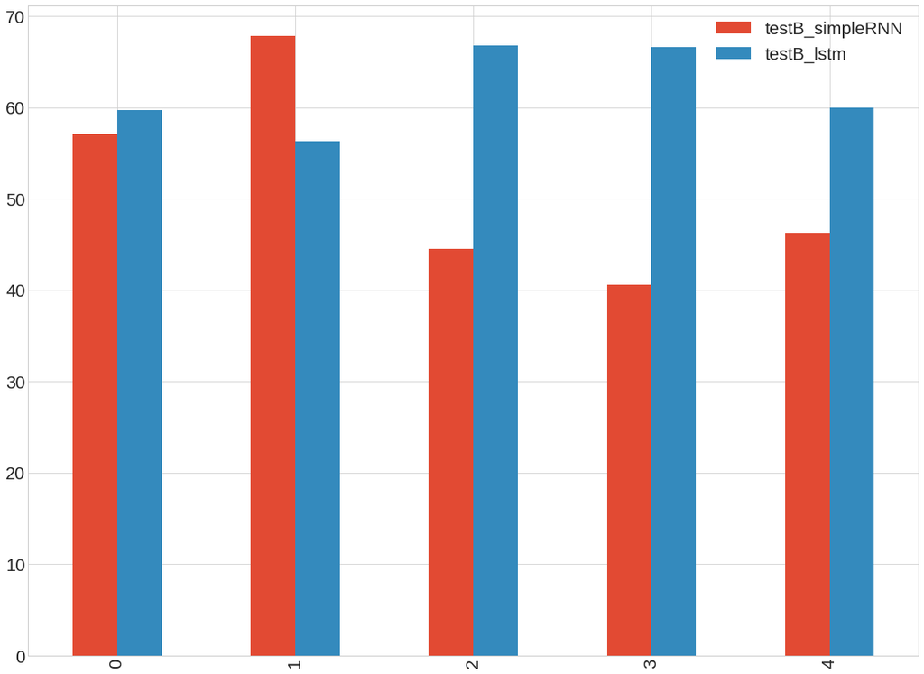

```python
df_all_test[['testB_simpleRNN','testB_lstm']].plot.bar()
```

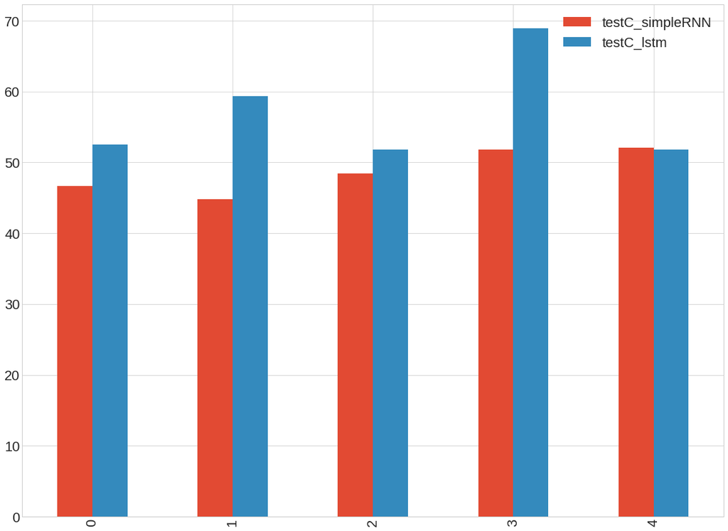

```python
df_all_test[['testC_simpleRNN','testC_lstm']].plot.bar()
```

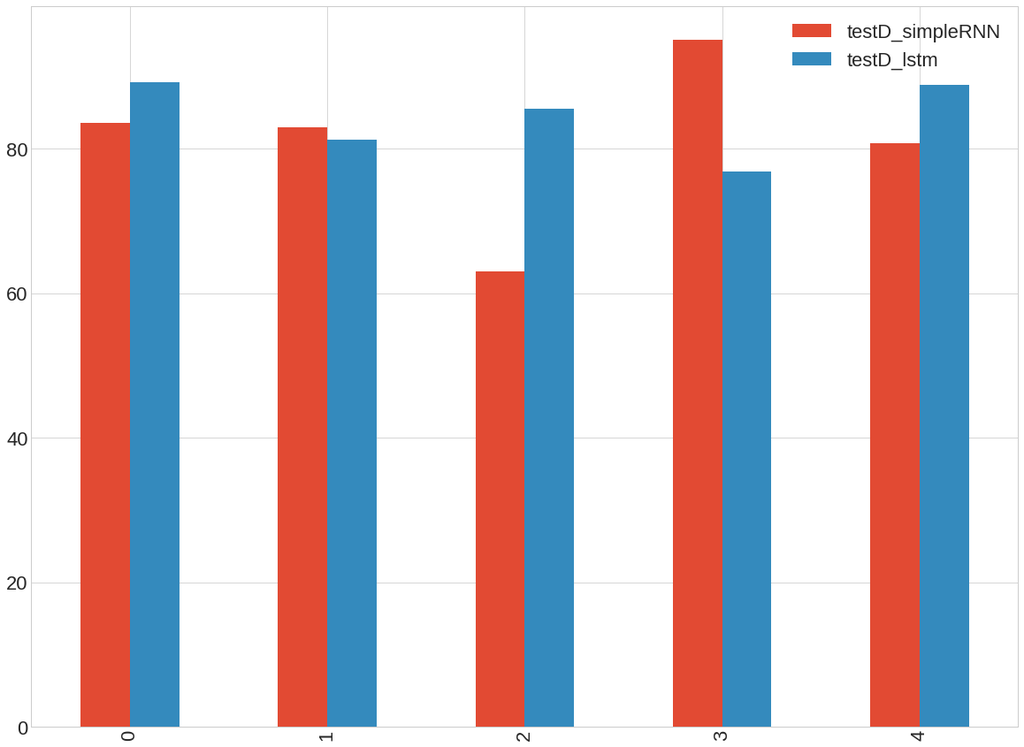

```python
df_all_test[['testD_simpleRNN','testD_lstm']].plot.bar()
```

#### Conclusiones

Casi en todos los casos la red `SimpleRNN` obtuvo menor RMSE que su contraparte. De los gráficos generales se puede ver como ejemplo, los resultados del caso B. Algunos comentarios al respecto se encuentran en el siguiente actividad.

[figure not shown]

## Actividad 12

Considerando

> `modelRNN.fit(trainX, trainY, nb epoch=150, batch size=5, verbose=2)`

De la documentación

> **`batch_size`**: `Integer or None. Number of samples per gradient update. If unspecified, it will default to 32.`

> **`epochs`**: `Integer. Number of epochs to train the model. An epoch is an iteration over the entire x and y data provided. Note that in conjunction with initial_epoch, epochs is to be understood as "final epoch". The model is not trained for a number of iterations given by epochs, but merely until the epoch of index epochs is reached.`

*batch size* se refiere a la cantidad de datos del dataset que son usados para actualizar el gradiente durante una época. Un tamaño menor de muestra permite un uso menor de memoria, aunque la trayectoria del gradiente presenta más ruido. Un caso es cuando `batch_size=1` el cual se conoce como descenso estocástico, el cual presenta el máximo de ruido.

[figure not shown]

*epochs* por otro lado, se refieren a las veces que el algoritmo entrena la red usando todo el conjunto de datos. Una época ocurre cuando la red ha visto todo el conjunto de datos. Considerando que al comienzo de cada época los datos son reordenados aleatoriamente, la red ve en cada vez un conjunto distinto y aprende un problema distinto. El *tradeoff* ocurre considerando que el entrenamiento es supervisado, i.e. a mayor cantidad de épocas la red puede perder la capacidad de generalización y viceversa.

*Epochs* y *Batch Size* son *hiperparámetros de la red*. Una discusión al respecto puede leerse [aquí](https://stats.stackexchange.com/questions/153531/what-is-batch-size-in-neural-network) y [aquí](https://stats.stackexchange.com/questions/164876/tradeoff-batch-size-vs-number-of-iterations-to-train-a-neural-network)

## Cambios en los hiperparámetros de la red LSTM

Si se entrena la red LSTM para el caso C, cambiando los hiperparámetros de la siguiente forma

`modelRNN.fit(trainX, trainY, epochs=10, batch_size=100, verbose=2)`

se tiene una red con pocas capacidades de generalizar, que obtiene un error relativamente bajo durante el entrenamiento pero muy alto durante la etapa de test, durante la cual la red trabaja sobre elementos nuevos.

```
DEBUG:airlineUtils:Train Score: 66.09 RMSE
DEBUG:airlineUtils:Test Score: 211.67 RMSE
```

[figure not shown]

Si se cambian los parámetros a

`modelRNN.fit(trainX, trainY, epochs=100, batch_size=20, verbose=2)`

La red tiene mejores resultados durante la etapa de test.

```
DEBUG:airlineUtils:Train Score: 29.76 RMSE
DEBUG:airlineUtils:Test Score: 64.97 RMSE
```

[figure not shown]

Finalmente, con los siguientes parámetros ocurre otra situación de *overfitting*

`modelRNN.fit(trainX, trainY, epochs=300, batch_size=1, verbose=2)`

```
DEBUG:airlineUtils:Train Score: 20.38 RMSE
DEBUG:airlineUtils:Test Score: 62.14 RMSE
```

En este caso las mejoras son pocas, pero el tiempo de entrenamiento se triplica. Se puede observar que la red aprende los ejemplos de entrenamiento logrando una copia casi idéntica. Esto puede ser útil para algunos problemas, y en este caso termina aportando al error.

[figure not shown]

Finalmente el caso con 150 épocas y *batch size* 1 da mejores resultados

```
DEBUG:airlineUtils:Train Score: 24.71 RMSE
DEBUG:airlineUtils:Test Score: 48.14 RMSE
```

[figure not shown]

Comparativamente, los resultados son mejores en la etapa de testing cuando batch size es mínimo.

```
Text(0.5,1,'Comparison in testing results')
```

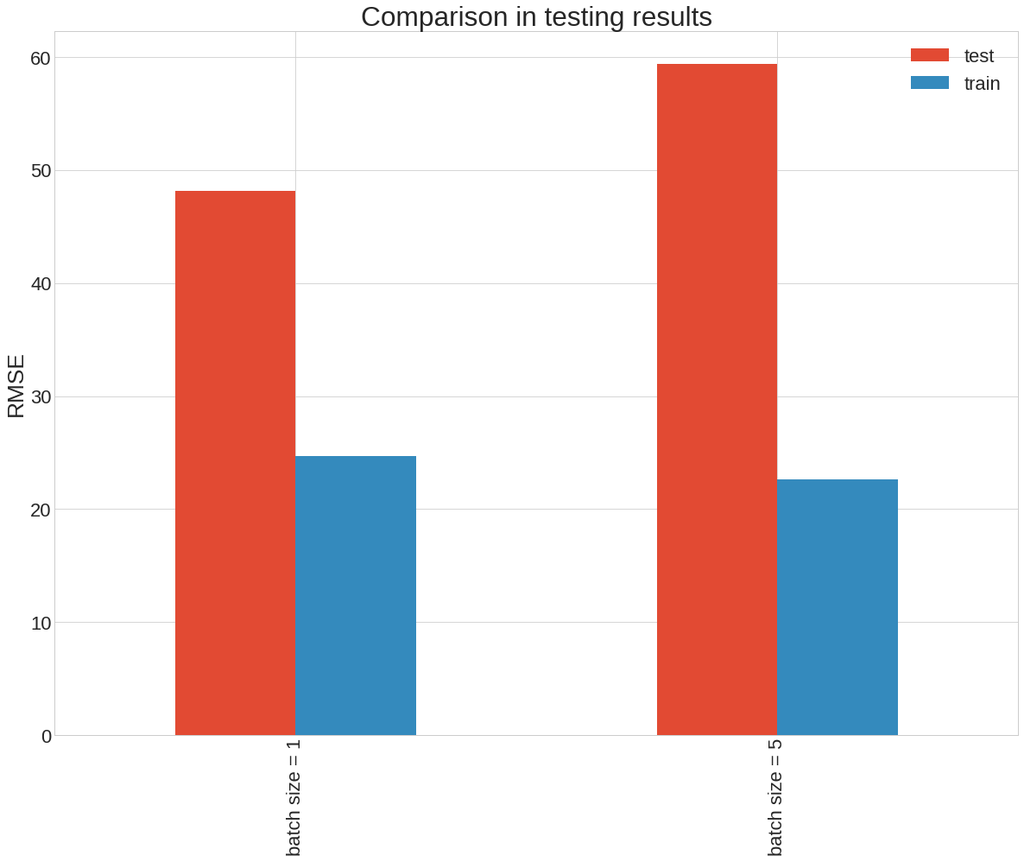

```python
train, test = test_lstm_train.loc[1,'train_caseC'], test_lstm_testing.loc[1,'test_caseC']
ax = pd.DataFrame({'test':{'batch5':test,'batch1':48.14},'train':{'batch5':train,'batch1':24.71}}).plot.bar()
ax.set_xticklabels(['batch size = 1', 'batch size = 5'])
ax.set_ylabel('RMSE')
ax.set_title('Comparison in testing results')
```